# Practical Machine Learning assignment Writeup

Ayushi Mehrotra

21/10/2020

# Introduction

The aim of the final project for the Practical Machine Learning course is to verify whether it is possible to understand whether the exercises were conducted correctly from the data provided by devices such as Jawbone Up and Fitbit.

The steps to follow to complete an analysis of this kind were outlined in the course and they are: query, data input, characteristics, algorithm, parameters and assessment; so I will follow this sequence for my task, but not point by point.

### Retrive and cleaning Data

So, loading all the library needed and then retrieving the data is the first thing. This original source is the data for this project: http:/groupware.les.inf.puc-rio.br / har.

```r
library(data.table) #load package data.table
library(mlbench) #load package mlbench
library(caret) #load package caret
library(klaR) #load package klaR
library(randomForest) #load package randomForest
library(rattle) #load package rattle
```

```r
library(rpart) #load package rpart
library(rpart.plot) #load package rpart.plot
```

The training data for this project are available here: https://d396qusza40orc.cloudfront.net/predmachlearn/pml-training.csv

The test data are available here: https://d396qusza40orc.cloudfront.net/predmachlearn/pml-testing.csv

```r
Train_Data <- fread("https://d396qusza40orc.cloudfront.net/predmachlearn/pml-training.csv", header=T, na.strings=c("NA","#DIV/0!",""))
Test_Data <- fread("http://d396qusza40orc.cloudfront.net/predmachlearn/pml-testing.csv", header=T, na.strings=c("NA","#DIV/0!",""))
dim(Train_Data)
```

```
## [1] 19622   160
```

```r
dim(Test_Data)
```

```
## [1]  20 160
```

“Now, we use the” summary(Training Date) “and” str(Training Date) “commands to look at the data and, since we have 160 columns, we extract the column names. we do not include the”summary" and “str” outputs because these commands extract a lot of rows, but we think it is useful to know the list of names.

```r
names(Train_Data)
```

```
##   [1] "V1"                       "user_name"
##   [3] "raw_timestamp_part_1"     "raw_timestamp_part_2"
##   [5] "cvtd_timestamp"           "new_window"
##   [7] "num_window"               "roll_belt"
##   [9] "pitch_belt"               "yaw_belt"
##  [11] "total_accel_belt"         "kurtosis_roll_belt"
##  [13] "kurtosis_picth_belt"      "kurtosis_yaw_belt"
##  [15] "skewness_roll_belt"       "skewness_roll_belt.1"
##  [17] "skewness_yaw_belt"        "max_roll_belt"
##  [19] "max_picth_belt"           "max_yaw_belt"
##  [21] "min_roll_belt"            "min_pitch_belt"
##  [23] "min_yaw_belt"             "amplitude_roll_belt"
##  [25] "amplitude_pitch_belt"     "amplitude_yaw_belt"
##  [27] "var_total_accel_belt"     "avg_roll_belt"
##  [29] "stddev_roll_belt"         "var_roll_belt"
```

[output cut: 65 more lines]

So we have many columns with “NA” values, and several columns also contain steps that at this time do not concern us (We want the belt, arm and forearm variables). The next move, therefore, is to construct a subset of data with measurements that interest me and add the “result” column. The first thing to do is to use “sapply” on the TrainingData and extract all NA or blank variables, then use the list to sub-set the main data set.

```r
List_Na <- sapply(Train_Data, function (x) any(is.na(x)))
newTrain_Data <- subset(Train_Data, select=c("classe", names(List_Na)[!List_Na & grepl("belt|[^(fore)]arm|dumbbell|forearm", names(List_Na))]))
```

Then, we have to convert class to a data type of Factor, so that caret generates a classification rather than a regression model.

```r
newTrain_Data <- newTrain_Data[, classe := factor(newTrain_Data[, classe])]
newTrain_Data[, .N, classe]
```

```
##    classe    N
## 1:      A 5580
## 2:      B 3797
## 3:      C 3422
## 4:      D 3216
## 5:      E 3607
```

The last thing to do is divide the training data into two batches, 60% training data and 40% test data.

```r
in_Train <- createDataPartition(newTrain_Data$classe, p=0.6, list=FALSE)
Train_data <- newTrain_Data[in_Train, ]
Test_data <- newTrain_Data[-in_Train, ]
```

Then we check if in the batch there are near-zero variance predictors

```r
nzv <- nearZeroVar(Train_data, saveMetrics=TRUE)
nzv
```

```
##                      freqRatio percentUnique zeroVar   nzv
## classe                1.469065    0.04245924   FALSE FALSE
## roll_belt             1.141473    8.65319293   FALSE FALSE
## pitch_belt            1.228571   13.85869565   FALSE FALSE
## yaw_belt              1.135314   14.57201087   FALSE FALSE
## total_accel_belt      1.075286    0.24626359   FALSE FALSE
## gyros_belt_x          1.020681    1.04449728   FALSE FALSE
## gyros_belt_y          1.132665    0.56046196   FALSE FALSE
## gyros_belt_z          1.076263    1.32472826   FALSE FALSE
## accel_belt_x          1.059574    1.35869565   FALSE FALSE
## accel_belt_y          1.087141    1.12941576   FALSE FALSE
## accel_belt_z          1.085551    2.44565217   FALSE FALSE
## magnet_belt_x         1.136792    2.51358696   FALSE FALSE
## magnet_belt_y         1.049875    2.42017663   FALSE FALSE
## magnet_belt_z         1.032609    3.64300272   FALSE FALSE
## roll_arm             53.210526   19.45482337   FALSE FALSE
## pitch_arm            77.769231   22.31657609   FALSE FALSE
## yaw_arm              33.700000   21.41644022   FALSE FALSE
## total_accel_arm       1.001838    0.56046196   FALSE FALSE
## gyros_arm_x           1.018927    5.25645380   FALSE FALSE
## gyros_arm_y           1.376997    3.09952446   FALSE FALSE
## gyros_arm_z           1.074074    1.97010870   FALSE FALSE
## accel_arm_x           1.038095    6.43682065   FALSE FALSE
## accel_arm_y           1.128788    4.48369565   FALSE FALSE
## accel_arm_z           1.012821    6.40285326   FALSE FALSE
## magnet_arm_x          1.092593   11.12432065   FALSE FALSE
## magnet_arm_y          1.250000    7.15862772   FALSE FALSE
## magnet_arm_z          1.115942   10.56385870   FALSE FALSE
## roll_dumbbell         1.090909   87.50849185   FALSE FALSE
## pitch_dumbbell        2.392857   85.24966033   FALSE FALSE
## yaw_dumbbell          1.011905   86.92255435   FALSE FALSE
## total_accel_dumbbell  1.089441    0.34816576   FALSE FALSE
## gyros_dumbbell_x      1.079019    1.91066576   FALSE FALSE
## gyros_dumbbell_y      1.231198    2.21637228   FALSE FALSE
## gyros_dumbbell_z      1.048913    1.57099185   FALSE FALSE
## accel_dumbbell_x      1.063725    3.44769022   FALSE FALSE
## accel_dumbbell_y      1.053333    3.86379076   FALSE FALSE
## accel_dumbbell_z      1.144828    3.37975543   FALSE FALSE
## magnet_dumbbell_x     1.000000    8.83152174   FALSE FALSE
## magnet_dumbbell_y     1.207547    6.81895380   FALSE FALSE
## magnet_dumbbell_z     1.130841    5.55366848   FALSE FALSE
## roll_forearm         11.859296   14.89470109   FALSE FALSE
## pitch_forearm        71.484848   21.02581522   FALSE FALSE
## yaw_forearm          14.472393   14.08797554   FALSE FALSE
## total_accel_forearm   1.113182    0.58593750   FALSE FALSE
## gyros_forearm_x       1.076923    2.32676630   FALSE FALSE
## gyros_forearm_y       1.012766    6.03770380   FALSE FALSE
## gyros_forearm_z       1.056478    2.38620924   FALSE FALSE
## accel_forearm_x       1.000000    6.49626359   FALSE FALSE
## accel_forearm_y       1.000000    8.26256793   FALSE FALSE
## accel_forearm_z       1.041237    4.67900815   FALSE FALSE
## magnet_forearm_x      1.019231   12.15183424   FALSE FALSE
## magnet_forearm_y      1.226415   15.30230978   FALSE FALSE
## magnet_forearm_z      1.083333   13.39164402   FALSE FALSE
```

We don’t have any predictors with near-zero variance so we can proceed with building our model.

### Building Model

To fit a model to the data we use the function “train” and a partial least squares discriminant analysis (PLSDA) model to start.

```r
set.seed(12345)
ctrl <- trainControl(method = "repeatedcv", repeats = 3, classProbs = TRUE, summaryFunction = defaultSummary)
plsFit <- train(classe ~ ., data = Train_data, method = "pls", tuneLength = 15, trControl = ctrl, metric = "ROC", preProc = c("center","scale"))
```

[output not shown]

[output cut: 166 more lines]

[output not shown]

```r
plsFit
```

```
## Partial Least Squares
##
## 11776 samples
##    52 predictor
##     5 classes: 'A', 'B', 'C', 'D', 'E'
##
## Pre-processing: centered (52), scaled (52)
## Resampling: Cross-Validated (10 fold, repeated 3 times)
## Summary of sample sizes: 10598, 10600, 10598, 10600, 10598, 10598, ...
## Resampling results across tuning parameters:
##
##   ncomp  Accuracy   Kappa
##    1     0.3286063  0.1119892
##    2     0.3438362  0.1343983
##    3     0.3691136  0.1793203
##    4     0.4545691  0.2955335
##    5     0.4909423  0.3447616
##    6     0.5027170  0.3608387
##    7     0.5294397  0.3956362
##    8     0.5433938  0.4147796
##    9     0.5639181  0.4424777
##   10     0.5780162  0.4609869
##   11     0.5814700  0.4657061
##   12     0.5870189  0.4728249
##   13     0.6059821  0.4967326
##   14     0.6101138  0.5020783
##   15     0.6143041  0.5074021
##
## Accuracy was used to select the optimal model using the largest value.
## The final value used for the model was ncomp = 15.
```

The grid of outcomes in this output is the average resampled performance estimates. Then we use “predict” on our test data to apply the model.

```r
plsClass <- predict(plsFit, newdata = Test_data)
str(plsClass)
```

```
##  Factor w/ 5 levels "A","B","C","D",..: 1 1 1 1 1 1 1 1 1 1 ...
```

We can also calculate this using the option type = “prob” to compute class probabilities from the model.

```r
plsProb <- predict(plsFit, newdata = Test_data, type = "prob")
head(plsProb)
```

```
##           A         B         C         D         E
## 1 0.3978188 0.1245560 0.1601190 0.1406748 0.1768314
## 2 0.3909499 0.1249454 0.1603996 0.1404210 0.1832841
## 3 0.3937321 0.1253093 0.1606493 0.1408250 0.1794843
## 4 0.3931051 0.1246000 0.1604178 0.1407772 0.1810999
## 5 0.3975638 0.1274761 0.1598829 0.1393962 0.1756810
## 6 0.4022957 0.1247325 0.1595291 0.1397421 0.1737005
```

#We use a plot to display the result in the best manner.

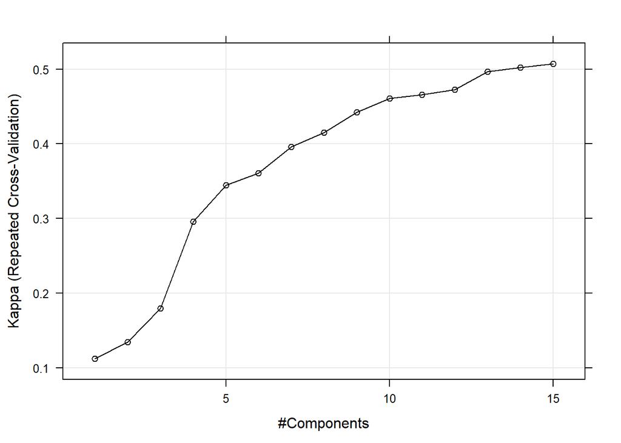

```r
trellis.par.set(caretTheme())
plot(plsFit, metric = "Kappa")
```

#We can apply another model like the “regularized discriminant analysis” model

```r
set.seed(123)
rdaFit <- train(classe ~ ., data = Train_data, method = "rda", tuneGrid = data.frame(gamma = (0:4)/4, lambda = 3/4), trControl = ctrl, metric = "ROC")
rdaFit
```

```
## Regularized Discriminant Analysis
##
## 11776 samples
##    52 predictor
##     5 classes: 'A', 'B', 'C', 'D', 'E'
##
## No pre-processing
## Resampling: Cross-Validated (10 fold, repeated 3 times)
## Summary of sample sizes: 10599, 10597, 10599, 10597, 10598, 10600, ...
## Resampling results across tuning parameters:
##
##   gamma  Accuracy   Kappa
##   0.00   0.8320323  0.7879299
##   0.25   0.5942045  0.4876304
##   0.50   0.5288446  0.4040900
##   0.75   0.4780638  0.3392612
##   1.00   0.4002519  0.2369021
##
## Tuning parameter 'lambda' was held constant at a value of 0.75
## Accuracy was used to select the optimal model using the largest value.
## The final values used for the model were gamma = 0 and lambda = 0.75.
```

```r
rdaClasses <- predict(rdaFit, newdata = Test_data)
confusionMatrix(rdaClasses, Test_data$classe)
```

```
## Confusion Matrix and Statistics
##
##           Reference
## Prediction    A    B    C    D    E
##          A 1947  172   20    7   14
##          B   24 1101   90    5   67
##          C  141  206 1208  196   94
##          D  111   27   44 1070   74
##          E    9   12    6    8 1193
##
## Overall Statistics
##
##                Accuracy : 0.8309
##                  95% CI : (0.8224, 0.8391)
##     No Information Rate : 0.2845
##     P-Value [Acc > NIR] : < 2.2e-16
##
##                   Kappa : 0.7866
##
##  Mcnemar's Test P-Value : < 2.2e-16
##
## Statistics by Class:
##
##                      Class: A Class: B Class: C Class: D Class: E
## Sensitivity            0.8723   0.7253   0.8830   0.8320   0.8273
## Specificity            0.9621   0.9706   0.9017   0.9610   0.9945
## Pos Pred Value         0.9014   0.8555   0.6547   0.8069   0.9715
## Neg Pred Value         0.9499   0.9364   0.9733   0.9669   0.9624
## Prevalence             0.2845   0.1935   0.1744   0.1639   0.1838
## Detection Rate         0.2482   0.1403   0.1540   0.1364   0.1521
## Detection Prevalence   0.2753   0.1640   0.2352   0.1690   0.1565
## Balanced Accuracy      0.9172   0.8480   0.8924   0.8965   0.9109
```

#and see how these two models (pls, rda) compare in terms of their resampling results.

```r
resamps <- resamples(list(pls = plsFit, rda = rdaFit))
summary(resamps)
```

```
##
## Call:
## summary.resamples(object = resamps)
##
## Models: pls, rda
## Number of resamples: 30
##
## Accuracy
##          Min.  1st Qu.    Median      Mean   3rd Qu.      Max. NA's
## pls 0.5780985 0.607219 0.6150255 0.6143041 0.6264347 0.6377551    0
## rda 0.8122345 0.821557 0.8336163 0.8320323 0.8400595 0.8486395    0
##
## Kappa
##          Min.   1st Qu.    Median      Mean   3rd Qu.      Max. NA's
## pls 0.4614141 0.4986558 0.5081207 0.5074021 0.5219044 0.5367467    0
## rda 0.7627893 0.7746962 0.7900334 0.7879299 0.7980705 0.8087550    0
```

```r
diffs <- diff(resamps)
summary(diffs)
```

```
##
## Call:
## summary.diff.resamples(object = diffs)
##
## p-value adjustment: bonferroni
## Upper diagonal: estimates of the difference
## Lower diagonal: p-value for H0: difference = 0
##
## Accuracy
##     pls       rda
## pls           -0.2177
## rda < 2.2e-16
##
## Kappa
##     pls       rda
## pls           -0.2805
## rda < 2.2e-16
```

#And then a plot to visualise the result

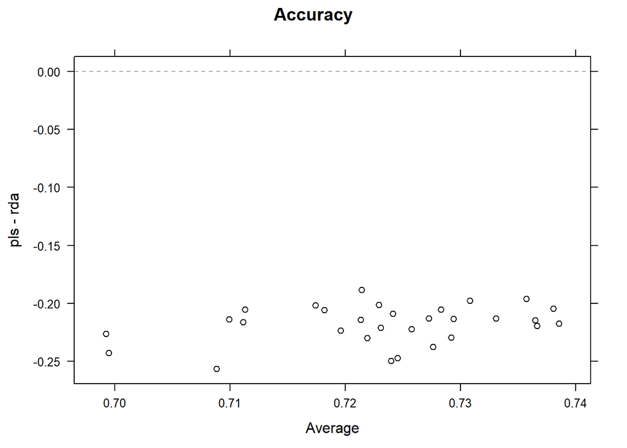

```r
xyplot(resamps, what = "BlandAltman")
```

#We can now also try the “Random Forest” model:

```r
rfFit <- train(classe~., data=Train_data, method="rf", tuneGrid=expand.grid(.mtry=sqrt(ncol(Train_data[,2:53]))), trControl=ctrl)
rfFit
```

```
## Random Forest
##
## 11776 samples
##    52 predictor
##     5 classes: 'A', 'B', 'C', 'D', 'E'
##
## No pre-processing
## Resampling: Cross-Validated (10 fold, repeated 3 times)
## Summary of sample sizes: 10599, 10598, 10598, 10600, 10598, 10597, ...
## Resampling results:
##
##   Accuracy   Kappa
##   0.9924135  0.9904029
##
## Tuning parameter 'mtry' was held constant at a value of 7.211103
```

```r
rfClasses <- predict(rfFit, newdata = Test_data)
confusionMatrix(rfClasses, Test_data$classe)
```

```
## Confusion Matrix and Statistics
##
##           Reference
## Prediction    A    B    C    D    E
##          A 2231    9    0    0    0
##          B    0 1503   11    0    0
##          C    0    6 1357    8    1
##          D    0    0    0 1274    4
##          E    1    0    0    4 1437
##
## Overall Statistics
##
##                Accuracy : 0.9944
##                  95% CI : (0.9925, 0.9959)
##     No Information Rate : 0.2845
##     P-Value [Acc > NIR] : < 2.2e-16
##
##                   Kappa : 0.9929
##
##  Mcnemar's Test P-Value : NA
##
## Statistics by Class:
##
##                      Class: A Class: B Class: C Class: D Class: E
## Sensitivity            0.9996   0.9901   0.9920   0.9907   0.9965
## Specificity            0.9984   0.9983   0.9977   0.9994   0.9992
## Pos Pred Value         0.9960   0.9927   0.9891   0.9969   0.9965
## Neg Pred Value         0.9998   0.9976   0.9983   0.9982   0.9992
## Prevalence             0.2845   0.1935   0.1744   0.1639   0.1838
## Detection Rate         0.2843   0.1916   0.1730   0.1624   0.1832
## Detection Prevalence   0.2855   0.1930   0.1749   0.1629   0.1838
## Balanced Accuracy      0.9990   0.9942   0.9948   0.9950   0.9979
```

```r
varImp(rfFit)
```

```
## rf variable importance
##
##   only 20 most important variables shown (out of 52)
##
##                      Overall
## roll_belt             100.00
## yaw_belt               74.69
## pitch_forearm          60.28
## magnet_dumbbell_z      59.95
## pitch_belt             56.96
## magnet_dumbbell_y      52.95
## roll_forearm           46.96
## magnet_dumbbell_x      38.66
## accel_dumbbell_y       31.99
## magnet_belt_z          30.79
## roll_dumbbell          30.73
## accel_belt_z           30.12
## magnet_belt_y          30.06
## accel_dumbbell_z       25.36
## gyros_belt_z           24.48
## accel_forearm_x        23.16
## roll_arm               22.03
## total_accel_dumbbell   19.04
## magnet_forearm_z       18.65
## yaw_dumbbell           17.60
```

```r
rfFit$finalModel
```

```
##
## Call:
##  randomForest(x = x, y = y, mtry = param$mtry)
##                Type of random forest: classification
##                      Number of trees: 500
## No. of variables tried at each split: 7
##
##         OOB estimate of  error rate: 0.7%
## Confusion matrix:
##      A    B    C    D    E  class.error
## A 3345    3    0    0    0 0.0008960573
## B   14 2255   10    0    0 0.0105309346
## C    0   16 2035    3    0 0.0092502434
## D    0    0   25 1905    0 0.0129533679
## E    0    0    3    9 2153 0.0055427252
```

## Conclusion

#Now We can try to use this model on our original tasting batch of data and so:

```r
Test_Result <- predict(rfFit, newdata=Test_Data)
Test_Result
```

```
##  [1] B A B A A E D B A A B C B A E E A B B B
## Levels: A B C D E
```